# Penentuan Model Terbaik Menggunakan Variable Selection, Ridge Regression dan Lasso Regression

Nazuwa Aulia

2023-09-29

# Library yang digunakan

```r
library(readxl)
library(stats)
library(base)
library(dplyr)
```

```r
library(corrplot)
library(ggplot2)
library(GGally)
library(car)
library(lmtest)
library(randtests)
library(MASS)
library(glmnet)
library(lmridge)
```

# Import data yang digunakan

Data yang digunakan bersumber dari kaggle dengan judul Student Performance. Terdapat total 10000 data namun pada analisis ini hanya 1000 data yang digunakan. Adapun peubah bebas yang digunakan sebanyak 4.

**Peubah Bebas (X)**

*Hours Studied* (X1), jumlah total jam yang dihabiskan siswa untuk belajar. *Previous Score* (X2), nilai yang diperoleh siswa dalam tes sebelumnya. *Sleep Hours* (X3), jumlah rata-rata jam tidur yang dimiliki siswa per hari. *Sample Question Papers Practiced* (X4), jumlah soal latihan yang dikerjakan oleh siswa.

**Peubah Respon (Y)**

*Performance Index*, ukuran kinerja keseluruhan setiap siswa. Indeks kinerja menggambarkan kinerja akademik siswa dan telah dibulatkan ke bilangan bulat terdekat. Indeks ini berkisar dari 10 hingga 100, dengan nilai yang lebih tinggi menunjukkan kinerja yang lebih baik.

```r
datapsd <- read_excel("C:/Users/Nazuwa Aulia/OneDrive/Documents/College/Semester 5/Pengantar Sains Data/student performance.xlsx", sheet = "Sheet2")
datapsd
```

```
## # A tibble: 1,000 × 5
##        y    x1    x2    x3    x4
##    <dbl> <dbl> <dbl> <dbl> <dbl>
##  1    91     7    99     9     1
##  2    65     4    82     4     2
##  3    45     8    51     7     2
##  4    36     5    52     5     2
##  5    66     7    75     8     5
##  6    61     3    78     9     6
##  7    63     7    73     5     6
##  8    42     8    45     4     6
##  9    61     5    77     8     2
## 10    69     4    89     4     0
## # ℹ 990 more rows
```

```r
str(datapsd)
```

```
## tibble [1,000 × 5] (S3: tbl_df/tbl/data.frame)
##  $ y : num [1:1000] 91 65 45 36 66 61 63 42 61 69 ...
##  $ x1: num [1:1000] 7 4 8 5 7 3 7 8 5 4 ...
##  $ x2: num [1:1000] 99 82 51 52 75 78 73 45 77 89 ...
##  $ x3: num [1:1000] 9 4 7 5 8 9 5 4 8 4 ...
##  $ x4: num [1:1000] 1 2 2 2 5 6 6 6 2 0 ...
```

# Eksplorasi Data

```r
summary(datapsd)
```

```
##        y                x1              x2              x3
##  Min.   : 10.00   Min.   :1.000   Min.   :40.00   Min.   :4.000
##  1st Qu.: 40.75   1st Qu.:3.000   1st Qu.:55.00   1st Qu.:5.000
##  Median : 56.00   Median :5.000   Median :70.00   Median :7.000
##  Mean   : 55.41   Mean   :4.898   Mean   :69.94   Mean   :6.516
##  3rd Qu.: 71.00   3rd Qu.:7.000   3rd Qu.:85.25   3rd Qu.:8.000
##  Max.   :100.00   Max.   :9.000   Max.   :99.00   Max.   :9.000
##        x4
##  Min.   :0.000
##  1st Qu.:2.000
##  Median :5.000
##  Mean   :4.484
##  3rd Qu.:7.000
##  Max.   :9.000
```

## Korelasi Peubah

### Pair plot

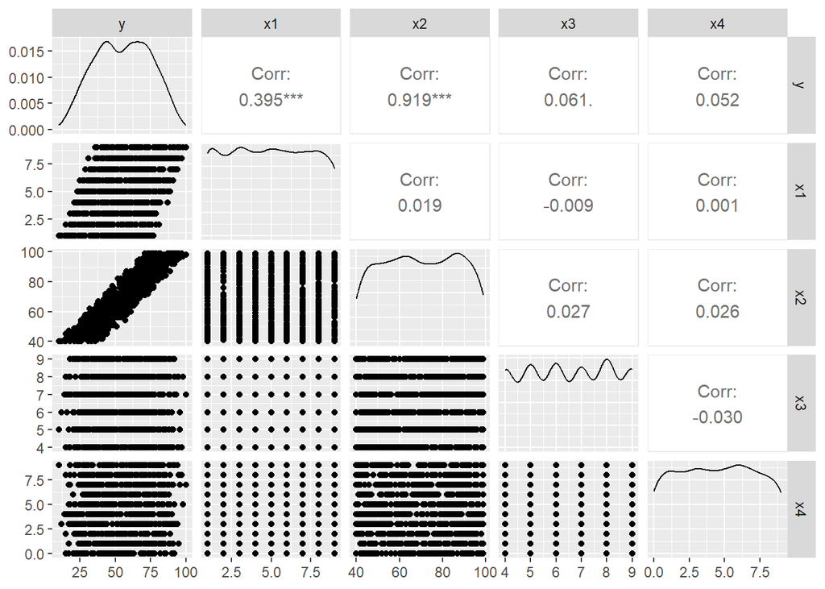

```r
ggpairs(datapsd)
```

Plot pair diatas menunjukkan menunjukkan hubungan antar peubah. Pada tabel nilai korelasi terdapat tanda bintang (*) yang menandakan adanya hubungan linier yang kuat atau signifikan dengan peubah respons, yaitu X1 dan X2. Meskipun nilai korelasi cenderung lemah, tidak ada peubah penjelas yang dieliminasi pada model awal karena akan dilakukan variable selection untuk melihat model terbaik.

### Matriks korelasi untuk setiap peubah numerik

```r
corr_matx <- datapsd %>% select_if(is.numeric) %>% cor() %>% round(3)
corr_matx
```

```
##        y     x1    x2     x3     x4
## y  1.000  0.395 0.919  0.061  0.052
## x1 0.395  1.000 0.019 -0.009  0.001
## x2 0.919  0.019 1.000  0.027  0.026
## x3 0.061 -0.009 0.027  1.000 -0.030
## x4 0.052  0.001 0.026 -0.030  1.000
```

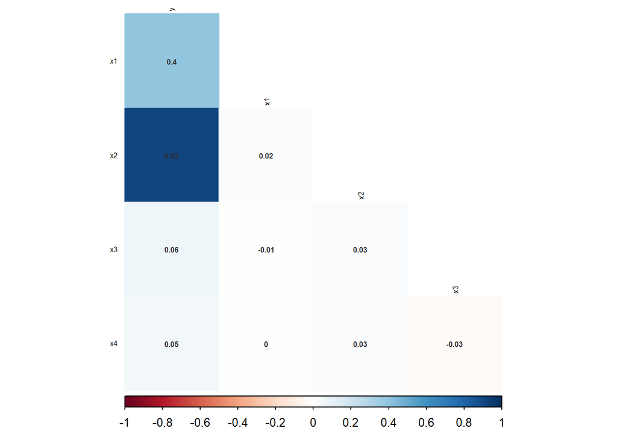

```r
corrplot(corr_matx,
         method = "color",
         type = "lower",
         tl.cex = 0.5,
         tl.col = "black",
         addCoef.col = "#2F2F2F",
         addCoefasPercent = FALSE,
         number.cex = 0.5,
         diag=F)
```

# Model Regresi Linear Berganda

```r
model.reg <- lm(y ~., data = datapsd)
summary(model.reg)
```

```
##
## Call:
## lm(formula = y ~ ., data = datapsd)
##
## Residuals:
##     Min      1Q  Median      3Q     Max
## -8.4160 -1.3150 -0.0403  1.2852  7.4600
##
## Coefficients:
##               Estimate Std. Error t value Pr(>|t|)
## (Intercept) -33.816104   0.391403 -86.397   <2e-16 ***
## x1            2.829452   0.024672 114.684   <2e-16 ***
## x2            1.021915   0.003707 275.635   <2e-16 ***
## x3            0.461903   0.037863  12.199   <2e-16 ***
## x4            0.197141   0.022865   8.622   <2e-16 ***
## ---
## Signif. codes:  0 '***' 0.001 '**' 0.01 '*' 0.05 '.' 0.1 ' ' 1
##
## Residual standard error: 2.03 on 995 degrees of freedom
## Multiple R-squared:  0.9892, Adjusted R-squared:  0.9891
## F-statistic: 2.274e+04 on 4 and 995 DF,  p-value: < 2.2e-16
```

Model regresi linear berganda yang diperoleh adalah :

$$\hat{y}=-33.816104+2.829452X_{1}+1.021915X_{2}+0.461903X_{i}+0.197141
X_{4}$$
Selain itu dapat dilihat nilai *Multiple R-squared* yang diperoleh sebesar 0.9892

# Pendeteksian Multikolinearitas

```r
car::vif(model.reg)
```

```
##       x1       x2       x3       x4
## 1.000450 1.001840 1.001763 1.001602
```

Multikolinieritas terdeteksi apabila nilai VIF lebih dari 10. Pada output diatas dapat dilihat bahwa hasil semua nilai VIF untuk setiap peubah kurang dari 10. Artinya, tidak ada multikolinieritas pada setiap peubah penjelas.

# Uji Asumsi

## Harapan Sisaan = 0

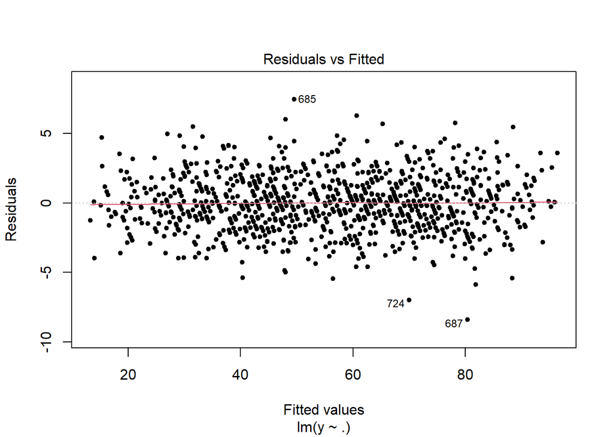

```r
plot(model.reg,1, pch=20)
```

```r
t.test(model.reg$residuals,mu = 0,conf.level = 0.95)
```

```
##
##  One Sample t-test
##
## data:  model.reg$residuals
## t = 1.9322e-15, df = 999, p-value = 1
## alternative hypothesis: true mean is not equal to 0
## 95 percent confidence interval:
##  -0.1257231  0.1257231
## sample estimates:
##    mean of x
## 1.237894e-16
```

Nilai *p-value* = 1 > 0.05 sehingga tak tolak H0 artinya nilai harapan sisaan = 0. Secara eksploratif juga dapat dilihat pada plot dimana sebagian besar sisaan berada di sekitar 0. Sehingga dapat disimpulkan bahwa terdapat cukup bukti untuk menyatakan nilai harapan sisaan = 0 dan **asumsi terpenuhi**

## Kehomogenan Sisaan

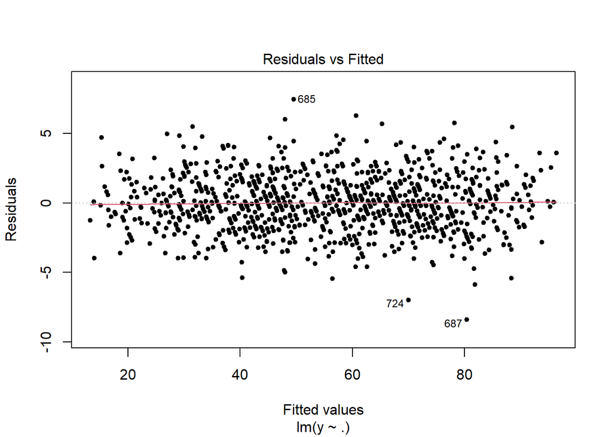

```r
plot(model.reg,1, pch=20)
```

```r
bptest(model.reg)
```

```
##
##  studentized Breusch-Pagan test
##
## data:  model.reg
## BP = 3.3844, df = 4, p-value = 0.4957
```

Nilai *p-value* = 0.4957 > 0.05 sehingga tak tolak H0 artinya ragam sisaan homogen. Secara eksploratif juga dapat dilihat pada plot dimana lebar pita sama untuk setiap nilai dugaan dan tidak membentuk seperti corong. Sehingga dapat disimpulkan bahwa terdapat cukup bukti untuk menyatakan ragam sisaan homogen dan **asumsi terpenuhi**

## Kesalingbebasan Sisaan

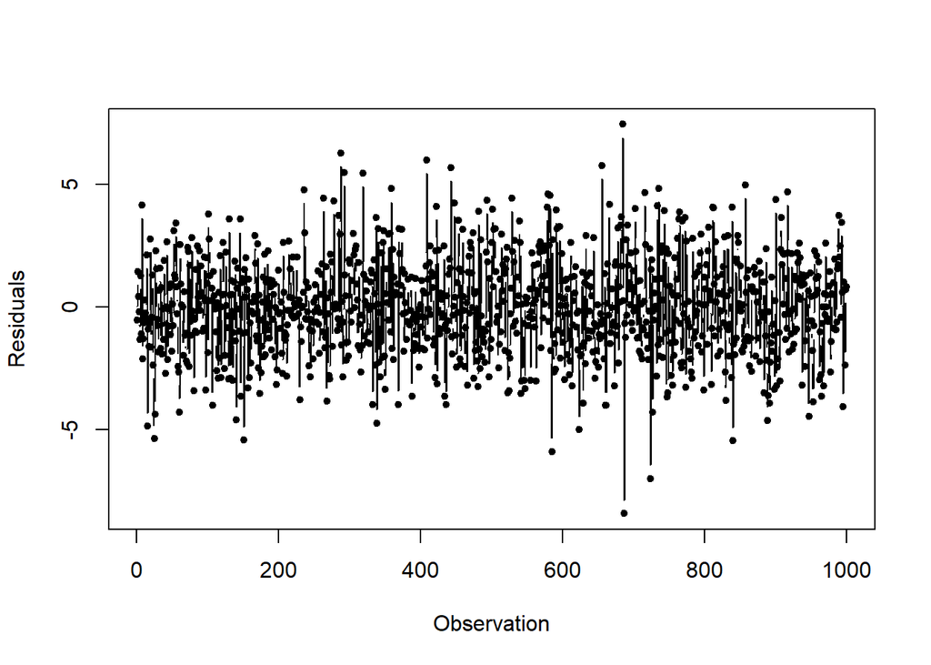

```r
plot(x = 1:dim(datapsd)[1],
     y = model.reg$residuals,
     type = 'b',
     ylab = "Residuals",
     xlab = "Observation", pch=20)
```

```r
dwtest(model.reg)
```

```
##
##  Durbin-Watson test
##
## data:  model.reg
## DW = 1.9771, p-value = 0.3592
## alternative hypothesis: true autocorrelation is greater than 0
```

```r
runs.test(model.reg$residuals)
```

```
##
##  Runs Test
##
## data:  model.reg$residuals
## statistic = -0.063277, runs = 500, n1 = 500, n2 = 500, n = 1000,
## p-value = 0.9495
## alternative hypothesis: nonrandomness
```

Nilai *p-value* = 0.3592 > 0.05 sehingga tak tolak H0 artinya sisaan saling bebas dan tidak terdapat autokorelasi. Secara eksploratif juga dapat dilihat pada plot dimana sisaan menyebar tak berpola, sehingga asumsi sisaan saling bebas terpenuhi. Sehingga dapat disimpulkan bahwa terdapat cukup bukti untuk menyatakan sisaan saling bebas dan **asumsi terpenuhi**

## Normalitas Sisaan

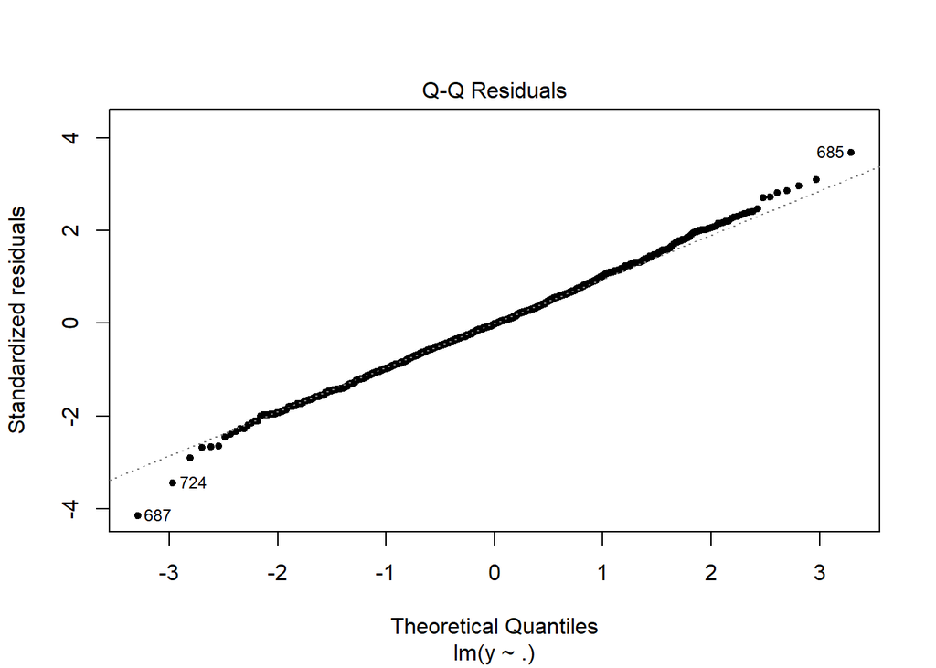

```r
plot(model.reg,2,pch=20)
```

```r
ks.test(model.reg$residuals, "pnorm", mean=mean(model.reg$residuals), sd=sd(model.reg$residuals))
```

```
##
##  Asymptotic one-sample Kolmogorov-Smirnov test
##
## data:  model.reg$residuals
## D = 0.021432, p-value = 0.7479
## alternative hypothesis: two-sided
```

Nilai *p-value* = 0.7479 > 0.05 sehingga tak tolak H0 artinya sisaan menyebar normal. Secara eksploratif juga dapat dilihat pada plot dimana banyak amatan telah mendekati garis qq-plot normal, sehingga asumsi sisaan menyebar normal terpenuhi. Sehingga dapat disimpulkan bahwa terdapat cukup bukti untuk menyatakan sisaan menyebar normal dan **asumsi terpenuhi**

# Variable Selection

## Forward Selection

```r
forward_model <- stepAIC(model.reg, direction = "forward")
```

```
## Start:  AIC=1421.13
## y ~ x1 + x2 + x3 + x4
```

## Backward Selection

```r
backward_model <- step(model.reg, direction = "backward")
```

```
## Start:  AIC=1421.13
## y ~ x1 + x2 + x3 + x4
##
##        Df Sum of Sq    RSS    AIC
## <none>                4101 1421.1
## - x4    1       306   4407 1491.2
## - x3    1       613   4714 1558.5
## - x1    1     54204  58304 4073.7
## - x2    1    313107 317207 5767.6
```

## Stepwise Selection

```r
stepwise_model <- stepAIC(model.reg, direction = "both")
```

```
## Start:  AIC=1421.13
## y ~ x1 + x2 + x3 + x4
##
##        Df Sum of Sq    RSS    AIC
## <none>                4101 1421.1
## - x4    1       306   4407 1491.2
## - x3    1       613   4714 1558.5
## - x1    1     54204  58304 4073.7
## - x2    1    313107 317207 5767.6
```

# Ridge Regression (glmnet)

```r
x<-data.matrix(datapsd[, c('x1', 'x2', 'x3', 'x4')])
y<-datapsd$y
```

## CV

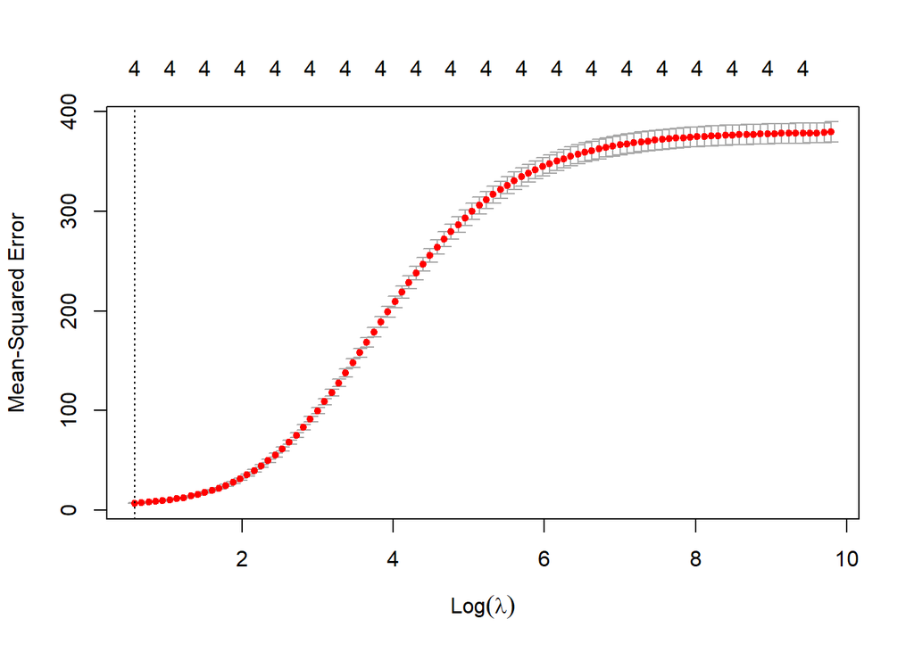

```r
cv.r<-cv.glmnet(x,y,alpha=0);plot(cv.r)
```

## Best Model

```r
best.lr<-cv.r$lambda.min
bestridge<-glmnet(x,y,alpha=0,lambda=best.lr);coef(bestridge)
```

```
## 5 x 1 sparse Matrix of class "dgCMatrix"
##                      s0
## (Intercept) -26.5793011
## x1            2.6010253
## x2            0.9365830
## x3            0.4416825
## x4            0.1930866
```

## R-Square

```r
rsq<-function(bestmodel,bestlambda,x,y){
 #y duga
 y.duga <- predict(bestmodel, s = bestlambda, newx = x)

 #JKG dan JKT
 jkt <- sum((y - mean(y))^2)
 jkg <- sum((y.duga- y)^2)

#find R-Squared
rsq <- 1 - jkg/jkt
return(rsq)
}
```

## R-Square Ridge

```r
rsq(bestridge,best.lr,x,y)
```

```
## [1] 0.9823767
```

# Lasso Regression

## CV

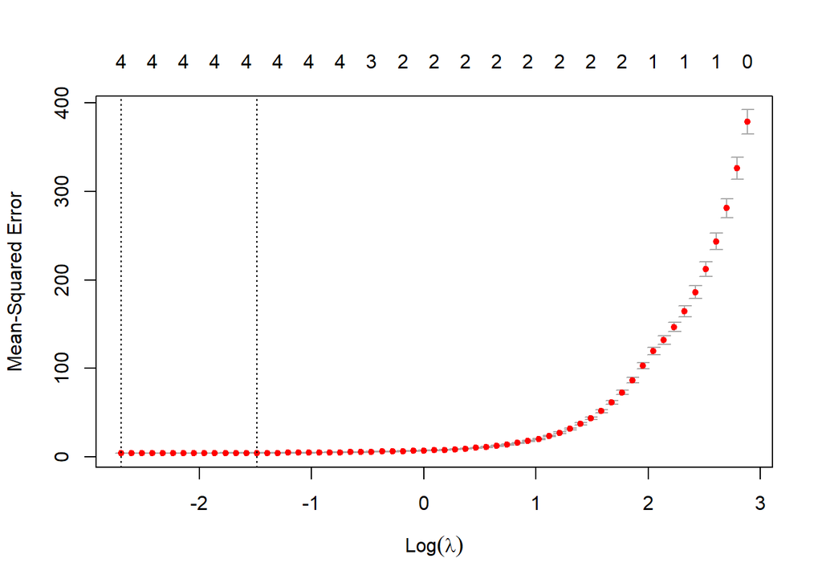

```r
cv.l<-cv.glmnet(x,y,alpha=1);plot(cv.l)
```

## Best Model

```r
best.ll<-cv.l$lambda.min
bestlasso<-glmnet(x,y,alpha=1,lambda=best.ll);coef(bestlasso)
```

```
## 5 x 1 sparse Matrix of class "dgCMatrix"
##                      s0
## (Intercept) -33.0685544
## x1            2.8038169
## x2            1.0183117
## x3            0.4216845
## x4            0.1730727
```

## R-Squared Lasso

```r
rsq(bestlasso,best.ll,x,y)
```

```
## [1] 0.9891326
```

# Ridge Regression (lmridge)

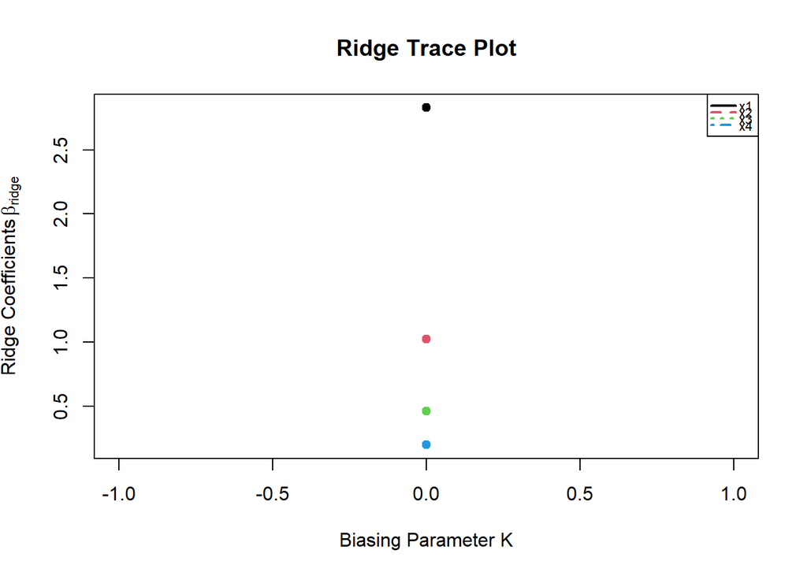

```
##          x1 x2      x3      x4
## k=0 0.00015  0 0.00035 0.00013
```

```r
lmr<-lmridge(y~.,datapsd,scaling="centered");plot(lmr);vif(lmr)
```

```r
summary(lmr)
```

```
##
## Call:
## lmridge.default(formula = y ~ ., data = datapsd, scaling = "centered")
##
##
## Coefficients: for Ridge parameter K= 0
##           Estimate Estimate (Sc) StdErr (Sc) t-value (Sc)  Pr(>|t|)
## Intercept -33.8161      -33.8161      0.7297     -46.3444 < 2.2e-16 ***
## x1          2.8294        2.8295      0.0247     114.7416 < 2.2e-16 ***
## x2          1.0219        1.0219      0.0037     275.7735 < 2.2e-16 ***
## x3          0.4619        0.4619      0.0378      12.2054 < 2.2e-16 ***
## x4          0.1971        0.1971      0.0229       8.6265 < 2.2e-16 ***
## ---
## Signif. codes:  0 '***' 0.001 '**' 0.01 '*' 0.05 '.' 0.1 ' ' 1
##
## Ridge Summary
##          R2      adj-R2    DF ridge           F         AIC         BIC
##     0.98920     0.98910     3.99999 22763.38879  1419.13130  8346.51755
## Ridge minimum MSE= 0.002576261 at K= 0
## P-value for F-test ( 3.99999 , 996 ) = 0
## -------------------------------------------------------------------
```

# Kesimpulan

Berdasarkan hasil analisis yang dilakukan melalui *variable selection*, *ridge regression* dan *lasso regression* model terbaik yang dihasilkan merupakan model awal yang memiliki 4 peubah bebas dengan nilai *R-Squared* nya sebesar 98.92%